# Homework 1

PSTAT 131

## Machine Learning Main Ideas

Please answer the following questions. Be sure that your solutions are clearly marked and that your document is neatly formatted.

You don’t have to rephrase everything in your own words, but if you quote directly, you should cite whatever materials you use (this can be as simple as “from the lecture/page # of book”).

### Question 1:

Define supervised and unsupervised learning. What are the difference(s) between them?

Supervised learning is where a model is trained to produce an output based off of an input or multiple inputs. Unsupervised learning is where a model is trained to produce an output, however there aren’t any supervised outputs that the model can learn from. The differences is that the supervised model has a training data set where the unsupervised only has the input data, another difference is that supervised learning is used for prediction where unsupervised learning is for analysis.

### Question 2:

Explain the difference between a regression model and a classification model, specifically in the context of machine learning.

The difference is that a regression model is usually made up of quantitative data, numerical values, and a classification model is usually made up of qualitative data, categorical values.

### Question 3:

Name two commonly used metrics for regression ML problems. Name two commonly used metrics for classification ML problems.

Regression ML: Mean Squared Error and R-squared

Classification ML: Error Rate and Precision

### Question 4:

As discussed, statistical models can be used for different purposes. These purposes can generally be classified into the following three categories. Provide a brief description of each.

- Descriptive models: Where statistical techniques are used to summarize the given data and understand it when it comes in large quantities.
- Inferential models: Where certain data points are put into the model in order for the model to give an output based on those points.
- Predictive models: Where given past data the model will be able to analyze and output a potential future outcome.

### Question 5:

Predictive models are frequently used in machine learning, and they can usually be described as either mechanistic or empirically-driven. Answer the following questions.

- Define mechanistic. Define empirically-driven. How do these model types differ? How are they similar?

A mechanistic model uses different sciences to explain a system’s behavior and processes. An empirically-driven model uses observations in the data in order to describe the relationships. These models are different in that mechanistic models are theory driven models whereas empirically-driven models are not based on any theory. Both use a data source to some extent to build their model off of and both produce an output whether a prediction, observation, or any other output.

- In general, is a mechanistic or empirically-driven model easier to understand? Explain your choice.

A mechanistic model is generally easier to understand, because it is based off of scientific methods to define a process that then goes towards an output, however an empirically-driven model doesn’t go off of theory and more off of observations, which makes it more of a black box system.

- Describe how the bias-variance trade off is related to the use of mechanistic or empirically-driven models.

It is related to the use of these models, because mechanistic models usually have higher bias, but a lower variance, whereas the empirically-drive model usually has a lower bias, but a higher variance.

### Question 6:

A political candidate’s campaign has collected some detailed voter history data from their constituents. The campaign is interested in two questions:

- Given a voter’s profile/data, how likely is it that they will vote in favor of the candidate?

This is predictive, because you are given the voter’s data in order to make an output using that data.

- How would a voter’s likelihood of support for the candidate change if they had personal contact with the candidate?

This is inferential, because you aren’t given any sort of historical data to get an output and instead are examining the relationship between two variables.

Classify each question as either predictive or inferential. Explain your reasoning for each.

## Exploratory Data Analysis

This section will ask you to complete several exercises. For this homework assignment, we’ll be working with the `mpg` data set that is loaded when you load the tidyverse. Make sure you load the tidyverse and any other packages you need.

Exploratory data analysis (or EDA) is not based on a specific set of rules or formulas. It is more of a state of curiosity about data. It’s an iterative process of:

- generating questions about data
- visualize and transform your data as necessary to get answers
- use what you learned to generate more questions

A couple questions are always useful when you start out. These are “what variation occurs within the variables,” and “what covariation occurs between the variables.”

You should use the tidyverse and `ggplot2` for these exercises.

### Exercise 1:

We are interested in highway miles per gallon, or the `hwy` variable. Create a histogram of this variable. Describe what you see/learn.

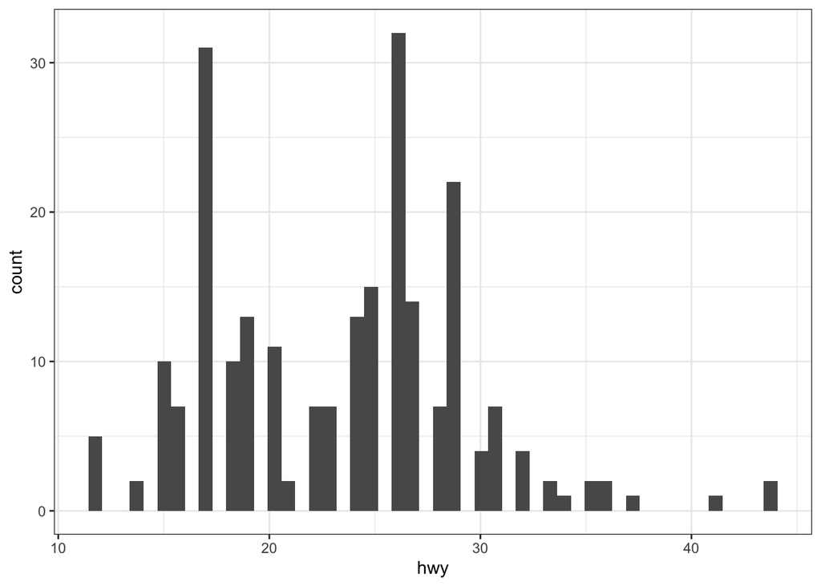

```r
mpg %>%
  ggplot(aes(x = hwy)) +
  geom_histogram(bins = 50) +
  theme_bw()
```

### Exercise 2:

Create a scatterplot. Put `hwy` on the x-axis and `cty` on the y-axis. Describe what you notice. Is there a relationship between `hwy` and `cty`? What does this mean?

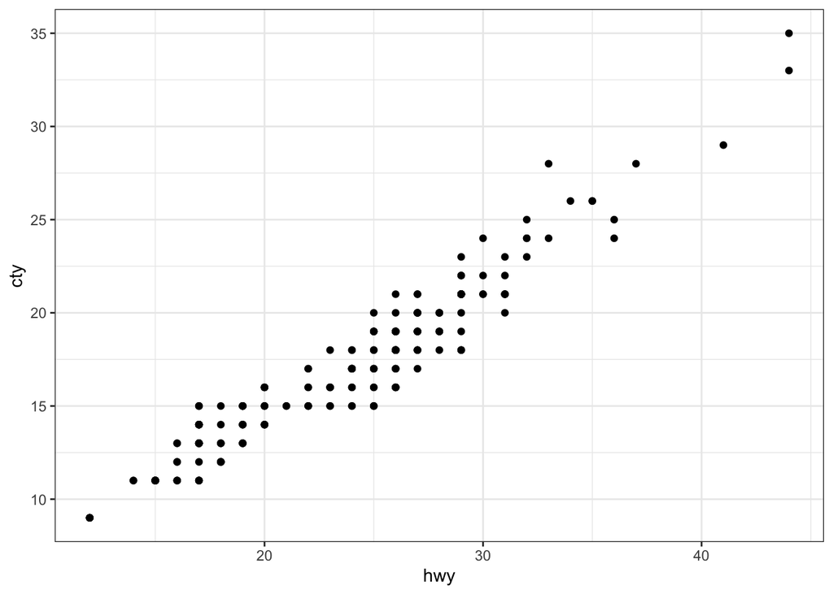

```r
mpg %>%
  ggplot(aes(x = hwy, y = cty)) +
  geom_point(bins = 60) +
  theme_bw()
```

### Exercise 3:

Make a bar plot of `manufacturer`. Flip it so that the manufacturers are on the y-axis. Order the bars by height. Which manufacturer produced the most cars? Which produced the least?

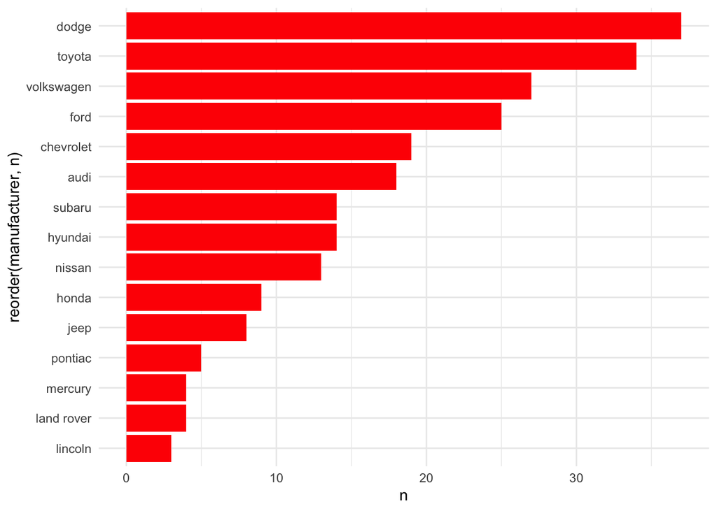

```r
production_count <- mpg %>%
  count(manufacturer) %>%
  arrange(desc(n))
ggplot(production_count, aes(x = reorder(manufacturer, n), y = n)) +
  geom_bar(stat = "identity", fill = "red") +
  coord_flip() +
  theme_minimal()
```

The manufacturer that produced the most cars was Dodge and the least amount of cars was Lincoln.

### Exercise 4:

Make a box plot of `hwy`, grouped by `cyl`. Use `geom_jitter()` and the `alpha` argument to add points to the plot.

Describe what you see. Is there a relationship between `hwy` and `cyl`? What do you notice?

### Exercise 5:

Use the `corrplot` package to make a lower triangle correlation matrix of the `mpg` dataset. (Hint: You can find information on the package [here.](https://cran.r-project.org/web/packages/corrplot/vignettes/corrplot-intro.html))

Which variables are positively or negatively correlated with which others? Do these relationships make sense to you? Are there any that surprise you?